# Machine Learning: HAR Data analysis

rachelxi

24 May 2015

## Introduction

This human activity recognition research has traditionally focused on discriminating between different activities, and the data set includes: six young health participants were asked to perform one set of 10 repetitions of the Unilateral Dumbbell Biceps Curl in five different fashions: exactly according to the specification (Class A), throwing the elbows to the front (Class B), lifting the dumbbell only halfway (Class C), lowering the dumbbell only halfway (Class D) and throwing the hips to the front (Class E).

Reference: Velloso, E.; Bulling, A.; Gellersen, H.; Ugulino, W.; Fuks, H. Qualitative Activity Recognition of Weight Lifting Exercises. Proceedings of 4th International Conference in Cooperation with SIGCHI (Augmented Human ’13) . Stuttgart, Germany: ACM SIGCHI, 2013.

## Synopsis

Cross-validation is achieved by splitting the data randomly by classe, with 75% goes for training data and rest 25% for validation.

## Data Preprocessing

First to load all library required and the data with NA replacement inserted to the data:

```r
library(caret)
library(rpart)
library(rattle)
library(randomForest)
data <- read.csv("pml-training.csv",na.strings = c("NA", "","#DIV/0!"))
dim(data)
```

```
## [1] 19622   160
```

As following table, the first seven rows of the data indicates row number, user names, time intervals and windows which are of no relation to prediction, so we can exclude them:

```r
head(data[,1:7],5)
```

```
##   X user_name raw_timestamp_part_1 raw_timestamp_part_2   cvtd_timestamp
## 1 1  carlitos           1323084231               788290 05/12/2011 11:23
## 2 2  carlitos           1323084231               808298 05/12/2011 11:23
## 3 3  carlitos           1323084231               820366 05/12/2011 11:23
## 4 4  carlitos           1323084232               120339 05/12/2011 11:23
## 5 5  carlitos           1323084232               196328 05/12/2011 11:23
##   new_window num_window
## 1         no         11
## 2         no         11
## 3         no         11
## 4         no         12
## 5         no         12
```

```r
data <- data[,-(1:7)]
```

Then, we convert the classe variable to factor for prediction; and further explore the number of NAs included in each column.

```r
data$classe <- as.factor(data$classe)
summary(colSums(is.na(data)))
```

```
##    Min. 1st Qu.  Median    Mean 3rd Qu.    Max.
##       0       0   19220   12580   19220   19620
```

Then we can filter the columns with major NAs included (<19000 out of 19622 rows).

```r
index <- colSums(is.na(data))<19000
data <- data[index]
dim(data)
```

```
## [1] 19622    53
```

Out of resulting data (size=19622*53), split the data randomly by classe with 75% for model training, 25% for validation to prepare for cross-validation:

```r
set.seed(2000)
inTrain <- createDataPartition(y=data$classe,p=0.75,list=FALSE)
training <- data[inTrain,]
validation <- data[-inTrain,]
```

The predictors with near to zero variance should be removed, thus we explore the training data further. No predictor should be removed according to following commands:

```r
nsv <- nearZeroVar(training,saveMetrics=TRUE)
sum(nsv$zeroVar=="TRUE")
```

```
## [1] 0
```

The preprocessing part is finished.

## Modelling

1. Model 1, using classification tree with “rpart”

Since the prediction is conducted with factor variable, classification tree is a good choice for identification. We can strat with “rpart” method, with method in trainControl() changed to “cv” for cross-validation. We can then plot the classification criteria:

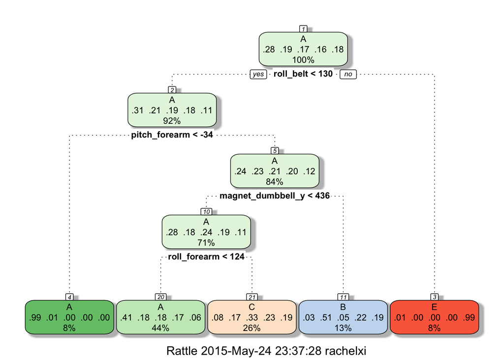

```r
modelFit1 <- train(classe~.,method="rpart",data=training,trControl = trainControl(method = "cv"))
fancyRpartPlot(modelFit1$finalModel)
```

Then to predict with the new built model 1 with both training and validation data:

```r
pred0 <- predict(modelFit1,newdata=training)
pred1 <- predict(modelFit1,newdata=validation)
confusionMatrix(pred0,training$classe)
```

```
## Confusion Matrix and Statistics
##
##           Reference
## Prediction    A    B    C    D    E
##          A 3808 1186 1196 1109  381
##          B   66  985   89  430  376
##          C  298  677 1282  873  749
##          D    0    0    0    0    0
##          E   13    0    0    0 1200
##
## Overall Statistics
##
##                Accuracy : 0.4943
##                  95% CI : (0.4862, 0.5024)
##     No Information Rate : 0.2843
##     P-Value [Acc > NIR] : < 2.2e-16
##
##                   Kappa : 0.3389
##  Mcnemar's Test P-Value : NA
##
## Statistics by Class:
##
##                      Class: A Class: B Class: C Class: D Class: E
## Sensitivity            0.9099  0.34586   0.4994   0.0000  0.44346
## Specificity            0.6324  0.91904   0.7863   1.0000  0.99892
## Pos Pred Value         0.4958  0.50617   0.3305      NaN  0.98928
## Neg Pred Value         0.9464  0.85413   0.8814   0.8361  0.88849
## Prevalence             0.2843  0.19350   0.1744   0.1639  0.18386
## Detection Rate         0.2587  0.06692   0.0871   0.0000  0.08153
## Detection Prevalence   0.5218  0.13222   0.2636   0.0000  0.08242
## Balanced Accuracy      0.7712  0.63245   0.6428   0.5000  0.72119
```

```r
confusionMatrix(pred1,validation$classe)
```

```
## Confusion Matrix and Statistics
##
##           Reference
## Prediction    A    B    C    D    E
##          A 1258  379  390  332  140
##          B   29  317   20  150  119
##          C  107  253  445  322  211
##          D    0    0    0    0    0
##          E    1    0    0    0  431
##
## Overall Statistics
##
##                Accuracy : 0.4998
##                  95% CI : (0.4857, 0.5139)
##     No Information Rate : 0.2845
##     P-Value [Acc > NIR] : < 2.2e-16
##
##                   Kappa : 0.3472
##  Mcnemar's Test P-Value : NA
##
## Statistics by Class:
##
##                      Class: A Class: B Class: C Class: D Class: E
## Sensitivity            0.9018  0.33404  0.52047   0.0000  0.47836
## Specificity            0.6463  0.91960  0.77945   1.0000  0.99975
## Pos Pred Value         0.5034  0.49921  0.33259      NaN  0.99769
## Neg Pred Value         0.9430  0.85196  0.88503   0.8361  0.89490
## Prevalence             0.2845  0.19352  0.17435   0.1639  0.18373
## Detection Rate         0.2565  0.06464  0.09074   0.0000  0.08789
## Detection Prevalence   0.5096  0.12949  0.27284   0.0000  0.08809
## Balanced Accuracy      0.7741  0.62682  0.64996   0.5000  0.73905
```

2. Model 2, random forest with principal component analysis

Then we can start model 2: random forest with pca. To begin with, data preprocessing is performed as below:

```r
proc <- preProcess(training[,-53],method="pca")
length(proc)
```

```
## [1] 19
```

```r
trainPC <- predict(proc,newdata=training[,-53])
validPC <-predict(proc,newdata=validation[,-53])
```

Then to train the model with transformed data: (the model training time is calculated as well for comparison)

```r
ptm <- proc.time()
modelFit2 <- train(training$classe~.,method="rf",data=trainPC,ntree=200,trControl=trainControl(method="cv"))
proc.time()-ptm
```

```
##    user  system elapsed
## 407.405   4.567 415.107
```

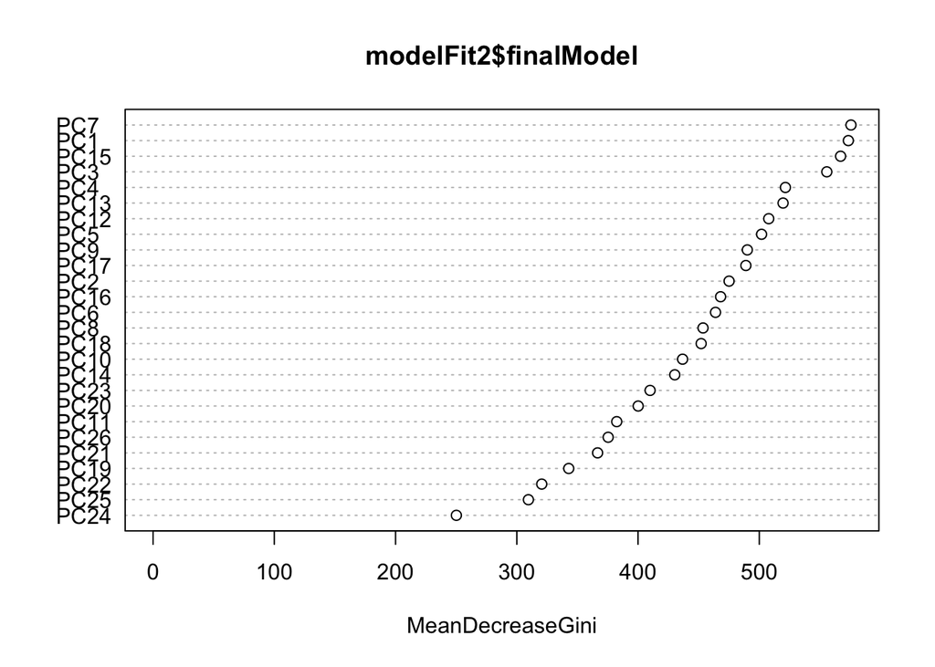

```r
pred2 <- predict(modelFit2,newdata=trainPC)
pred3 <- predict(modelFit2,newdata=validPC)
varImpPlot(modelFit2$finalModel)
```

Hence for the new model 2, the accuracy for training data is 100% and 97.96% for validation data. The accuracy rate is quite high.

```r
confusionMatrix(pred2,training$classe)
```

```
## Confusion Matrix and Statistics
##
##           Reference
## Prediction    A    B    C    D    E
##          A 4185    0    0    0    0
##          B    0 2848    0    0    0
##          C    0    0 2567    0    0
##          D    0    0    0 2412    0
##          E    0    0    0    0 2706
##
## Overall Statistics
##
##                Accuracy : 1
##                  95% CI : (0.9997, 1)
##     No Information Rate : 0.2843
##     P-Value [Acc > NIR] : < 2.2e-16
##
##                   Kappa : 1
##  Mcnemar's Test P-Value : NA
##
## Statistics by Class:
##
##                      Class: A Class: B Class: C Class: D Class: E
## Sensitivity            1.0000   1.0000   1.0000   1.0000   1.0000
## Specificity            1.0000   1.0000   1.0000   1.0000   1.0000
## Pos Pred Value         1.0000   1.0000   1.0000   1.0000   1.0000
## Neg Pred Value         1.0000   1.0000   1.0000   1.0000   1.0000
## Prevalence             0.2843   0.1935   0.1744   0.1639   0.1839
## Detection Rate         0.2843   0.1935   0.1744   0.1639   0.1839
## Detection Prevalence   0.2843   0.1935   0.1744   0.1639   0.1839
## Balanced Accuracy      1.0000   1.0000   1.0000   1.0000   1.0000
```

```r
confusionMatrix(pred3,validation$classe)
```

```
## Confusion Matrix and Statistics
##
##           Reference
## Prediction    A    B    C    D    E
##          A 1386   18    3    1    0
##          B    4  916   10    0    0
##          C    2   14  837   30    3
##          D    2    0    5  770    3
##          E    1    1    0    3  895
##
## Overall Statistics
##
##                Accuracy : 0.9796
##                  95% CI : (0.9753, 0.9834)
##     No Information Rate : 0.2845
##     P-Value [Acc > NIR] : < 2.2e-16
##
##                   Kappa : 0.9742
##  Mcnemar's Test P-Value : NA
##
## Statistics by Class:
##
##                      Class: A Class: B Class: C Class: D Class: E
## Sensitivity            0.9935   0.9652   0.9789   0.9577   0.9933
## Specificity            0.9937   0.9965   0.9879   0.9976   0.9988
## Pos Pred Value         0.9844   0.9849   0.9447   0.9872   0.9944
## Neg Pred Value         0.9974   0.9917   0.9955   0.9918   0.9985
## Prevalence             0.2845   0.1935   0.1743   0.1639   0.1837
## Detection Rate         0.2826   0.1868   0.1707   0.1570   0.1825
## Detection Prevalence   0.2871   0.1896   0.1807   0.1591   0.1835
## Balanced Accuracy      0.9936   0.9808   0.9834   0.9776   0.9960
```

3. Model 3, random forest with all variables included

Without preprocessing using pca analysis, the model 3 directly introduces random forest to build the model and perform the predictions as following.

```r
ptm <- proc.time()
modelFit3 <- train(classe~.,method="rf",data=training,ntree=200,trControl=trainControl(method="cv"))
proc.time()-ptm
```

```
##    user  system elapsed
## 771.007   5.386 780.378
```

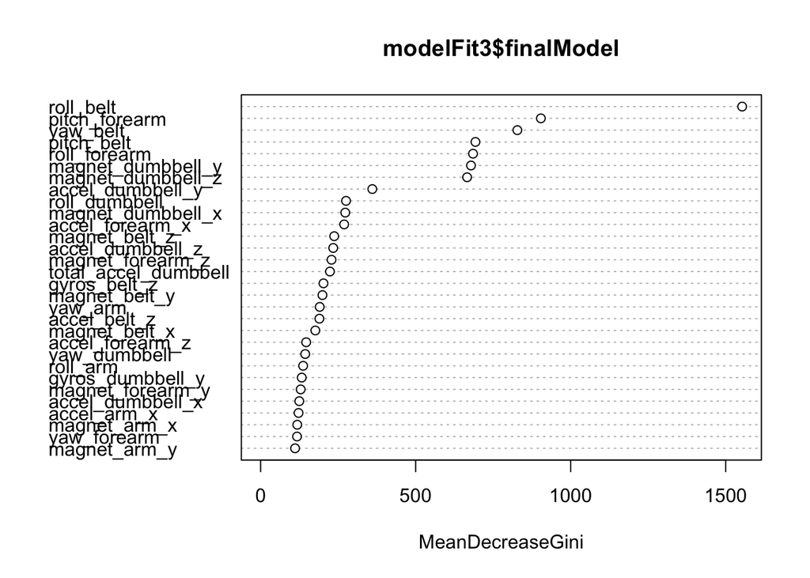

```r
pred4 <- predict(modelFit3,newdata=training)
pred5 <- predict(modelFit3,newdata=validation)
varImpPlot(modelFit3$finalModel)
```

```r
confusionMatrix(pred4,training$classe)
```

```
## Confusion Matrix and Statistics
##
##           Reference
## Prediction    A    B    C    D    E
##          A 4185    0    0    0    0
##          B    0 2848    0    0    0
##          C    0    0 2567    0    0
##          D    0    0    0 2412    0
##          E    0    0    0    0 2706
##
## Overall Statistics
##
##                Accuracy : 1
##                  95% CI : (0.9997, 1)
##     No Information Rate : 0.2843
##     P-Value [Acc > NIR] : < 2.2e-16
##
##                   Kappa : 1
##  Mcnemar's Test P-Value : NA
##
## Statistics by Class:
##
##                      Class: A Class: B Class: C Class: D Class: E
## Sensitivity            1.0000   1.0000   1.0000   1.0000   1.0000
## Specificity            1.0000   1.0000   1.0000   1.0000   1.0000
## Pos Pred Value         1.0000   1.0000   1.0000   1.0000   1.0000
## Neg Pred Value         1.0000   1.0000   1.0000   1.0000   1.0000
## Prevalence             0.2843   0.1935   0.1744   0.1639   0.1839
## Detection Rate         0.2843   0.1935   0.1744   0.1639   0.1839
## Detection Prevalence   0.2843   0.1935   0.1744   0.1639   0.1839
## Balanced Accuracy      1.0000   1.0000   1.0000   1.0000   1.0000
```

```r
confusionMatrix(pred5,validation$classe)
```

```
## Confusion Matrix and Statistics
##
##           Reference
## Prediction    A    B    C    D    E
##          A 1391    6    0    0    0
##          B    2  937    4    1    0
##          C    1    6  849   12    0
##          D    0    0    2  790    2
##          E    1    0    0    1  899
##
## Overall Statistics
##
##                Accuracy : 0.9923
##                  95% CI : (0.9894, 0.9945)
##     No Information Rate : 0.2845
##     P-Value [Acc > NIR] : < 2.2e-16
##
##                   Kappa : 0.9902
##  Mcnemar's Test P-Value : NA
##
## Statistics by Class:
##
##                      Class: A Class: B Class: C Class: D Class: E
## Sensitivity            0.9971   0.9874   0.9930   0.9826   0.9978
## Specificity            0.9983   0.9982   0.9953   0.9990   0.9995
## Pos Pred Value         0.9957   0.9926   0.9781   0.9950   0.9978
## Neg Pred Value         0.9989   0.9970   0.9985   0.9966   0.9995
## Prevalence             0.2845   0.1935   0.1743   0.1639   0.1837
## Detection Rate         0.2836   0.1911   0.1731   0.1611   0.1833
## Detection Prevalence   0.2849   0.1925   0.1770   0.1619   0.1837
## Balanced Accuracy      0.9977   0.9928   0.9941   0.9908   0.9986
```

## Prediction with testing data

Pre-processing:

Then we can perform prediction to testing data with same pre-processing first:

```r
testing <- read.csv("pml-testing.csv",na.strings = c("NA", "","#DIV/0!"))
testing <- testing[,-(1:7)]
index <- colSums(is.na(testing))==0
testing <- testing[index]
```

Prediction using Model 2:

```r
testPC <- predict(proc,newdata=testing[,-53])
prediction2 <- predict(modelFit2,newdata=testPC)
```

Prediction using Model 3:

```r
prediction3 <- predict(modelFit3,newdata=testing[,-53])
```

Sum the difference:

```r
sum(prediction2!=prediction3)
```

```
## [1] 1
```